# Лабораторная работа №5

Кластерный и регрессионный анализ данных с использованием языка R

Быков Александр 231-332

2026-02-06

# Введение

В данной лабораторной работе рассматриваются методы машинного обучения:

- **K-ближайших соседей (KNN)** — непараметрический метод классификации
- **Метод опорных векторов (SVM)** — алгоритм построения оптимальной разделяющей гиперплоскости
- **Анализ главных компонент (PCA)** — метод снижения размерности данных

# Задание 2: Классификация методом k-ближайших соседей

## 2.1 Загрузка и исследование данных

```r
# Загружаем датасет iris
data(iris)

# Структура данных
str(iris)
```

```
## 'data.frame':    150 obs. of  5 variables:
##  $ Sepal.Length: num  5.1 4.9 4.7 4.6 5 5.4 4.6 5 4.4 4.9 ...
##  $ Sepal.Width : num  3.5 3 3.2 3.1 3.6 3.9 3.4 3.4 2.9 3.1 ...
##  $ Petal.Length: num  1.4 1.4 1.3 1.5 1.4 1.7 1.4 1.5 1.4 1.5 ...
##  $ Petal.Width : num  0.2 0.2 0.2 0.2 0.2 0.4 0.3 0.2 0.2 0.1 ...
##  $ Species     : Factor w/ 3 levels "setosa","versicolor",..: 1 1 1 1 1 1 1 1 1 1 ...
```

```r
# Распределение по классам
table(iris$Species)
```

```
##
##     setosa versicolor  virginica
##         50         50         50
```

```r
# Процентное соотношение классов
round(prop.table(table(iris$Species)) * 100, digits = 1)
```

```
##
##     setosa versicolor  virginica
##       33.3       33.3       33.3
```

## 2.2 Визуализация данных

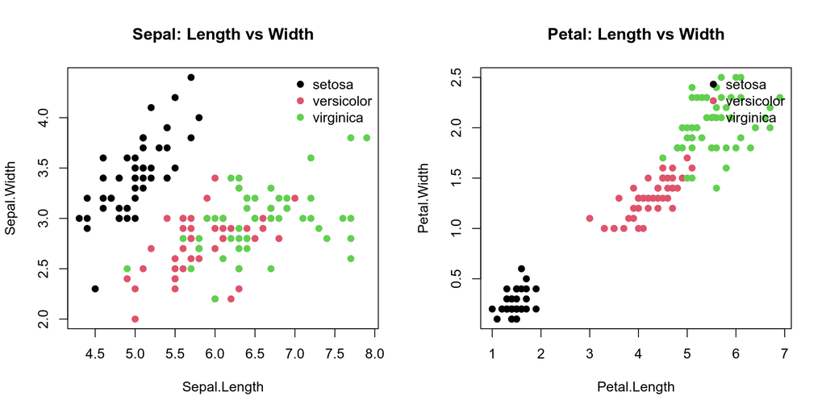

```r
par(mfrow = c(1, 2))

# График Sepal.Length vs Sepal.Width
plot(iris$Sepal.Length, iris$Sepal.Width,
     col = iris$Species, pch = 19,
     xlab = "Sepal.Length", ylab = "Sepal.Width",
     main = "Sepal: Length vs Width")
legend("topright", legend = levels(iris$Species),
       bty = "n", pch = 19, col = 1:3)

# График Petal.Length vs Petal.Width
plot(iris$Petal.Length, iris$Petal.Width,
     col = iris$Species, pch = 19,
     xlab = "Petal.Length", ylab = "Petal.Width",
     main = "Petal: Length vs Width")
legend("topright", legend = levels(iris$Species),
       bty = "n", pch = 19, col = 1:3)
```

**Наблюдение**: Видно, что setosa хорошо отделяется от других видов, в то время как versicolor и virginica частично перекрываются.

## 2.3 Нормализация данных

Алгоритм KNN сильно зависит от масштаба признаков, поэтому необходима нормализация:

```r
# Функция min-max нормализации
normMinMax <- function(x) {
  return((x - min(x)) / (max(x) - min(x)))
}

# Применяем нормализацию к числовым признакам
iris_norm <- as.data.frame(lapply(iris[1:4], normMinMax))

# Проверяем результат
summary(iris_norm)
```

```
##   Sepal.Length     Sepal.Width      Petal.Length     Petal.Width
##  Min.   :0.0000   Min.   :0.0000   Min.   :0.0000   Min.   :0.00000
##  1st Qu.:0.2222   1st Qu.:0.3333   1st Qu.:0.1017   1st Qu.:0.08333
##  Median :0.4167   Median :0.4167   Median :0.5678   Median :0.50000
##  Mean   :0.4287   Mean   :0.4406   Mean   :0.4675   Mean   :0.45806
##  3rd Qu.:0.5833   3rd Qu.:0.5417   3rd Qu.:0.6949   3rd Qu.:0.70833
##  Max.   :1.0000   Max.   :1.0000   Max.   :1.0000   Max.   :1.00000
```

После нормализации все признаки находятся в диапазоне [0, 1].

## 2.4 Разделение на обучающую и тестовую выборки

```r
set.seed(1234)

# Случайное разделение: 70% обучающая, 30% тестовая
indexes <- sample(2, nrow(iris), replace = TRUE, prob = c(0.7, 0.3))

# Обучающая выборка (признаки)
iris_train <- iris_norm[indexes == 1, ]
# Тестовая выборка (признаки)
iris_test <- iris_norm[indexes == 2, ]

# Метки классов
iris_train_labels <- iris[indexes == 1, 5]
iris_test_labels <- iris[indexes == 2, 5]

cat("Размер обучающей выборки:", nrow(iris_train), "\n")
```

```
## Размер обучающей выборки: 112
```

```r
cat("Размер тестовой выборки:", nrow(iris_test), "\n")
```

```
## Размер тестовой выборки: 38
```

## 2.5 Построение модели KNN

```r
library(class)

# Построение модели KNN с k=3
iris_mdl <- knn(train = iris_train,
                test = iris_test,
                cl = iris_train_labels,
                k = 3)

# Результаты предсказания
cat("Предсказанные классы:\n")
```

```
## Предсказанные классы:
```

```r
print(iris_mdl)
```

```
##  [1] setosa     setosa     setosa     setosa     setosa     setosa
##  [7] setosa     setosa     setosa     setosa     versicolor versicolor
## [13] versicolor versicolor versicolor versicolor versicolor versicolor
## [19] versicolor versicolor versicolor versicolor virginica  virginica
## [25] virginica  virginica  versicolor virginica  virginica  virginica
## [31] virginica  virginica  versicolor virginica  virginica  virginica
## [37] virginica  virginica
## Levels: setosa versicolor virginica
```

## 2.6 Оценка модели с помощью CrossTable

```r
library(gmodels)

# CrossTable для оценки модели
CrossTable(x = iris_test_labels,
           y = iris_mdl,
           prop.chisq = FALSE)
```

```
##
##
##    Cell Contents
## |-------------------------|
## |                       N |
## |           N / Row Total |
## |           N / Col Total |
## |         N / Table Total |
## |-------------------------|
##
##
## Total Observations in Table:  38
##
##
##                  | iris_mdl
## iris_test_labels |     setosa | versicolor |  virginica |  Row Total |
## -----------------|------------|------------|------------|------------|
##           setosa |         10 |          0 |          0 |         10 |
##                  |      1.000 |      0.000 |      0.000 |      0.263 |
##                  |      1.000 |      0.000 |      0.000 |            |
##                  |      0.263 |      0.000 |      0.000 |            |
## -----------------|------------|------------|------------|------------|
##       versicolor |          0 |         12 |          0 |         12 |
##                  |      0.000 |      1.000 |      0.000 |      0.316 |
##                  |      0.000 |      0.857 |      0.000 |            |
##                  |      0.000 |      0.316 |      0.000 |            |
## -----------------|------------|------------|------------|------------|
##        virginica |          0 |          2 |         14 |         16 |
##                  |      0.000 |      0.125 |      0.875 |      0.421 |
##                  |      0.000 |      0.143 |      1.000 |            |
##                  |      0.000 |      0.053 |      0.368 |            |
## -----------------|------------|------------|------------|------------|
##     Column Total |         10 |         14 |         14 |         38 |
##                  |      0.263 |      0.368 |      0.368 |            |
## -----------------|------------|------------|------------|------------|
##
##
```

## 2.7 Матрица ошибок (Confusion Matrix)

```r
# Построение матрицы ошибок
CM <- table(Факт = iris_test_labels, Прогноз = iris_mdl)
print(CM)
```

```
##             Прогноз
## Факт     setosa versicolor virginica
##   setosa         10          0         0
##   versicolor      0         12         0
##   virginica       0          2        14
```

### Интерпретация матрицы ошибок

- **True Positive (TP)**: Правильно классифицированные объекты каждого класса (диагональные элементы)
- **False Positive (FP)**: Объекты, ошибочно отнесённые к данному классу
- **False Negative (FN)**: Объекты данного класса, ошибочно отнесённые к другим классам

## 2.8 Диагональная оценка качества прогноза (Accuracy)

```r
# Расчёт точности (accuracy)
accuracy <- sum(diag(CM)) / sum(CM)
cat("Точность модели (Accuracy):", round(accuracy * 100, 2), "%\n")
```

```
## Точность модели (Accuracy): 94.74 %
```

```r
# Детальный анализ по классам
cat("\nКоличество правильных классификаций:", sum(diag(CM)), "\n")
```

```
##
## Количество правильных классификаций: 36
```

```r
cat("Общее количество наблюдений:", sum(CM), "\n")
```

```
## Общее количество наблюдений: 38
```

**Вывод**: Модель KNN с k=3 показывает высокую точность на датасете iris. Большинство ошибок связано с путаницей между versicolor и virginica, что объясняется их схожестью.

## 2.9 Исследование влияния параметра k

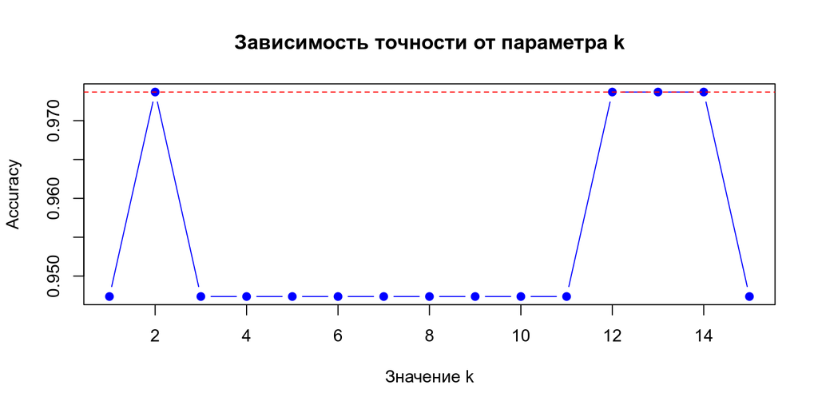

```r
# Проверка разных значений k
k_values <- 1:15
accuracies <- sapply(k_values, function(k) {
  pred <- knn(train = iris_train, test = iris_test,
              cl = iris_train_labels, k = k)
  mean(pred == iris_test_labels)
})

# Визуализация
plot(k_values, accuracies, type = "b",
     xlab = "Значение k", ylab = "Accuracy",
     main = "Зависимость точности от параметра k",
     pch = 19, col = "blue")
abline(h = max(accuracies), lty = 2, col = "red")
```

```r
cat("Лучшее значение k:", k_values[which.max(accuracies)],
    "с точностью", round(max(accuracies) * 100, 2), "%\n")
```

```
## Лучшее значение k: 2 с точностью 97.37 %
```

# Задание 3: Метод опорных векторов (SVM)

## 3.1 Подготовка данных

Для демонстрации SVM используем датасет iris с бинарной классификацией:

```r
library(e1071)

# Загрузка данных
data(iris)

# Преобразуем в задачу бинарной классификации
# Класс 1: setosa, Класс 2: versicolor + virginica
iris_svm <- iris
iris_svm$Class <- as.factor(ifelse(iris$Species == "setosa", "Setosa", "Other"))

# Проверка распределения
table(iris_svm$Class)
```

```
##
##  Other Setosa
##    100     50
```

## 3.2 Построение линейного SVM-классификатора

```r
# Построение SVM с линейным ядром и 10-fold перекрестной проверкой
svm_model <- svm(formula = Class ~ Sepal.Length + Sepal.Width +
                          Petal.Length + Petal.Width,
                 data = iris_svm,
                 cross = 10,
                 kernel = "linear")

# Информация о модели
print(svm_model)
```

```
##
## Call:
## svm(formula = Class ~ Sepal.Length + Sepal.Width + Petal.Length +
##     Petal.Width, data = iris_svm, cross = 10, kernel = "linear")
##
##
## Parameters:
##    SVM-Type:  C-classification
##  SVM-Kernel:  linear
##        cost:  1
##
## Number of Support Vectors:  4
```

## 3.3 Результаты перекрестной проверки

```r
# Точность на перекрестной проверке
cat("Точность 10-fold CV:", round(svm_model$tot.accuracy, 2), "%\n")
```

```
## Точность 10-fold CV: 100 %
```

```r
# Предсказания модели
svm_predictions <- predict(svm_model)

# Матрица ошибок
svm_CM <- table(Факт = iris_svm$Class, Прогноз = svm_predictions)
print(svm_CM)
```

```
##         Прогноз
## Факт Other Setosa
##   Other    100      0
##   Setosa     0     50
```

```r
# Точность on training data
svm_accuracy <- mean(svm_predictions == iris_svm$Class)
cat("\nТочность на обучающих данных:", round(svm_accuracy * 100, 2), "%\n")
```

```
##
## Точность на обучающих данных: 100 %
```

## 3.4 Визуализация опорных векторов

```r
# Количество опорных векторов
cat("Количество опорных векторов:", svm_model$tot.nSV, "\n")
```

```
## Количество опорных векторов: 4
```

```r
cat("Опорные векторы по классам:", svm_model$nSV, "\n")
```

```
## Опорные векторы по классам: 2 2
```

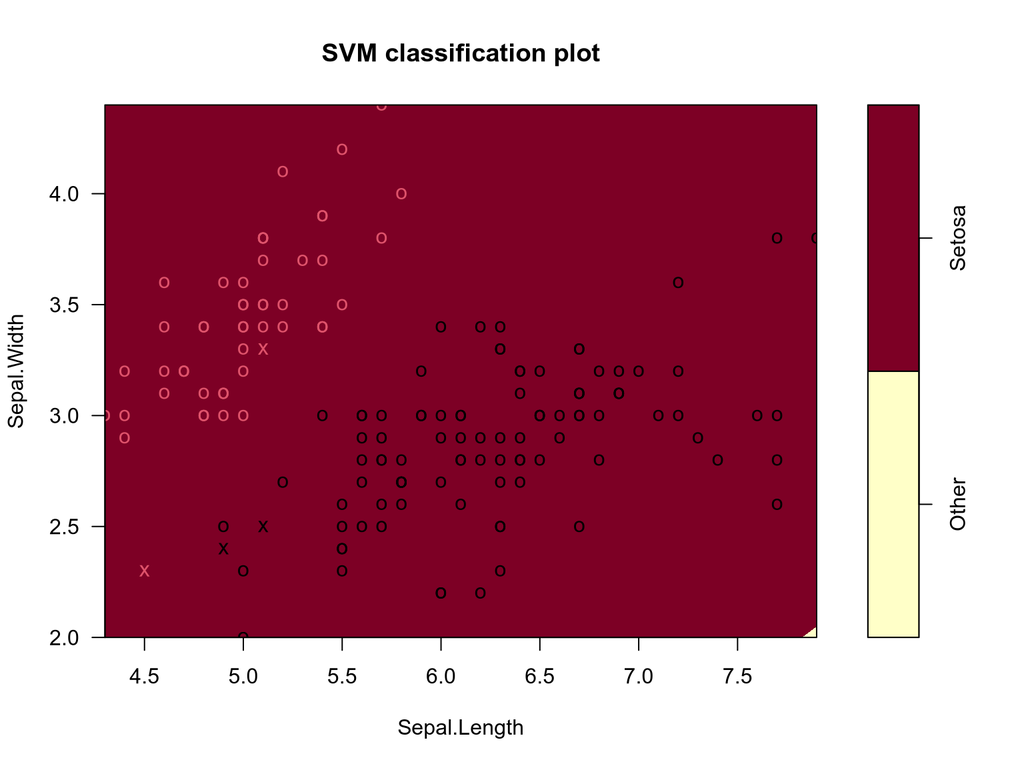

```r
# Визуализация (используем первые 2 признака для наглядности)
plot(svm_model, iris_svm, Sepal.Width ~ Sepal.Length,
     main = "SVM: Sepal.Width vs Sepal.Length")
```

## 3.5 Многоклассовая SVM-классификация

Рассмотрим также полную трёхклассовую задачу:

```r
# SVM для всех трёх классов
svm_multi <- svm(formula = Species ~ .,
                 data = iris,
                 cross = 10,
                 kernel = "linear")

cat("Точность многоклассовой SVM (10-fold CV):",
    round(svm_multi$tot.accuracy, 2), "%\n")
```

```
## Точность многоклассовой SVM (10-fold CV): 96 %
```

```r
# Матрица ошибок
multi_pred <- predict(svm_multi)
multi_CM <- table(Факт = iris$Species, Прогноз = multi_pred)
print(multi_CM)
```

```
##             Прогноз
## Факт     setosa versicolor virginica
##   setosa         50          0         0
##   versicolor      0         46         4
##   virginica       0          1        49
```

**Вывод**: - Линейный SVM-классификатор эффективно разделяет setosa от других видов с высокой точностью. - При многоклассовой классификации SVM также показывает хорошие результаты. - 10-fold перекрестная проверка (cross=10) позволяет получить более надёжную оценку качества модели.

# Задание 4: Анализ главных компонент (PCA)

## 4.1 Подготовка данных

```r
library(vegan)
library(ggplot2)

# Используем числовые признаки iris
Y <- iris[, 1:4]

# Описательные статистики
summary(Y)
```

```
##   Sepal.Length    Sepal.Width     Petal.Length    Petal.Width
##  Min.   :4.300   Min.   :2.000   Min.   :1.000   Min.   :0.100
##  1st Qu.:5.100   1st Qu.:2.800   1st Qu.:1.600   1st Qu.:0.300
##  Median :5.800   Median :3.000   Median :4.350   Median :1.300
##  Mean   :5.843   Mean   :3.057   Mean   :3.758   Mean   :1.199
##  3rd Qu.:6.400   3rd Qu.:3.300   3rd Qu.:5.100   3rd Qu.:1.800
##  Max.   :7.900   Max.   :4.400   Max.   :6.900   Max.   :2.500
```

## 4.2 Расчёт главных компонент

```r
# Выполняем PCA с помощью rda() из пакета vegan
mod_pca <- rda(Y ~ 1)

# Полный отчёт PCA
summary(mod_pca)
```

```
##
## Call:
## rda(formula = Y ~ 1)
##
## Partitioning of variance:
##               Inertia Proportion
## Total           4.573          1
## Unconstrained   4.573          1
##
## Eigenvalues, and their contribution to the variance
##
## Importance of components:
##                          PC1     PC2     PC3      PC4
## Eigenvalue            4.2282 0.24267 0.07821 0.023835
## Proportion Explained  0.9246 0.05307 0.01710 0.005212
## Cumulative Proportion 0.9246 0.97769 0.99479 1.000000
```

## 4.3 Собственные значения и доля объяснённой дисперсии

```r
# Собственные значения
eigenvalues <- mod_pca$CA$eig
cat("Собственные значения (eigenvalues):\n")
```

```
## Собственные значения (eigenvalues):
```

```r
print(round(eigenvalues, 4))
```

```
##    PC1    PC2    PC3    PC4
## 4.2282 0.2427 0.0782 0.0238
```

```r
# Доля объяснённой дисперсии
prop_var <- eigenvalues / sum(eigenvalues)
cumulative_var <- cumsum(prop_var)

variance_table <- data.frame(
  PC = paste0("PC", 1:length(eigenvalues)),
  Eigenvalue = round(eigenvalues, 4),
  Proportion = round(prop_var * 100, 2),
  Cumulative = round(cumulative_var * 100, 2)
)
print(variance_table)
```

```
##      PC Eigenvalue Proportion Cumulative
## PC1 PC1     4.2282      92.46      92.46
## PC2 PC2     0.2427       5.31      97.77
## PC3 PC3     0.0782       1.71      99.48
## PC4 PC4     0.0238       0.52     100.00
```

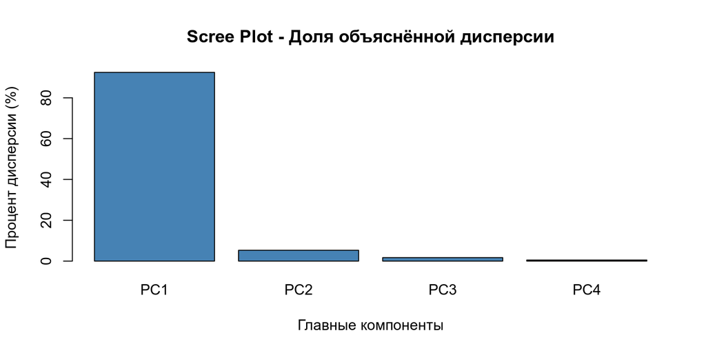

```r
# Scree plot
barplot(prop_var * 100, names.arg = paste0("PC", 1:length(eigenvalues)),
        main = "Scree Plot - Доля объяснённой дисперсии",
        ylab = "Процент дисперсии (%)",
        xlab = "Главные компоненты",
        col = "steelblue")
```

## 4.4 Нагрузки (Loadings)

```r
# Нагрузки переменных на главные компоненты
loadings <- scores(mod_pca, display = "species")
cat("Нагрузки переменных на главные компоненты:\n")
```

```
## Нагрузки переменных на главные компоненты:
```

```r
print(round(loadings, 4))
```

```
##                  PC1     PC2
## Sepal.Length  1.7754 -0.7728
## Sepal.Width  -0.4152 -0.8594
## Petal.Length  4.2086  0.2041
## Petal.Width   1.7602  0.0888
## attr(,"const")
## [1] 5.109117
```

## 4.5 Ординационная диаграмма

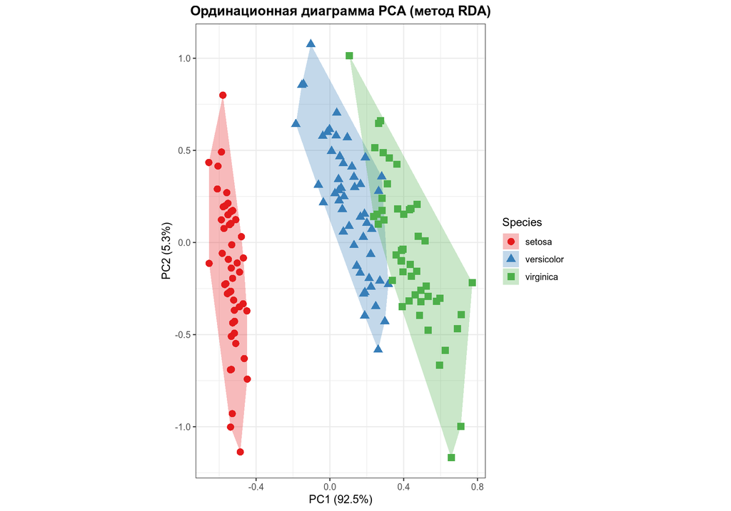

```r
# Получаем координаты наблюдений
pca_scores <- as.data.frame(scores(mod_pca, display = "sites")[, 1:2])
colnames(pca_scores) <- c("PC1", "PC2")
pca_scores$Species <- iris$Species

# Включаем доли объяснённой дисперсии в названия осей
axX <- paste("PC1 (",
             round(100 * mod_pca$CA$eig[1] / sum(mod_pca$CA$eig), 1), "%)", sep = "")
axY <- paste("PC2 (",
             round(100 * mod_pca$CA$eig[2] / sum(mod_pca$CA$eig), 1), "%)", sep = "")

# Каркас (hull) для выделения классов на диаграмме
hull <- do.call(rbind, lapply(unique(pca_scores$Species), function(s) {
  f <- subset(pca_scores, Species == s)
  f[chull(f$PC1, f$PC2), ]
}))

# Построение ординационной диаграммы
ggplot() +
  geom_polygon(data = hull, aes(x = PC1, y = PC2, fill = Species),
               alpha = 0.3, linetype = 0) +
  geom_point(data = pca_scores,
             aes(x = PC1, y = PC2, shape = Species, colour = Species),
             size = 3) +
  scale_colour_manual(values = c("setosa" = "#E41A1C",
                                  "versicolor" = "#377EB8",
                                  "virginica" = "#4DAF4A")) +
  scale_fill_manual(values = c("setosa" = "#E41A1C",
                                "versicolor" = "#377EB8",
                                "virginica" = "#4DAF4A")) +
  xlab(axX) + ylab(axY) +
  ggtitle("Ординационная диаграмма PCA (метод RDA)") +
  coord_equal() +
  theme_bw() +
  theme(legend.position = "right",
        plot.title = element_text(hjust = 0.5, face = "bold"))
```

## 4.6 Биплот с нагрузками переменных

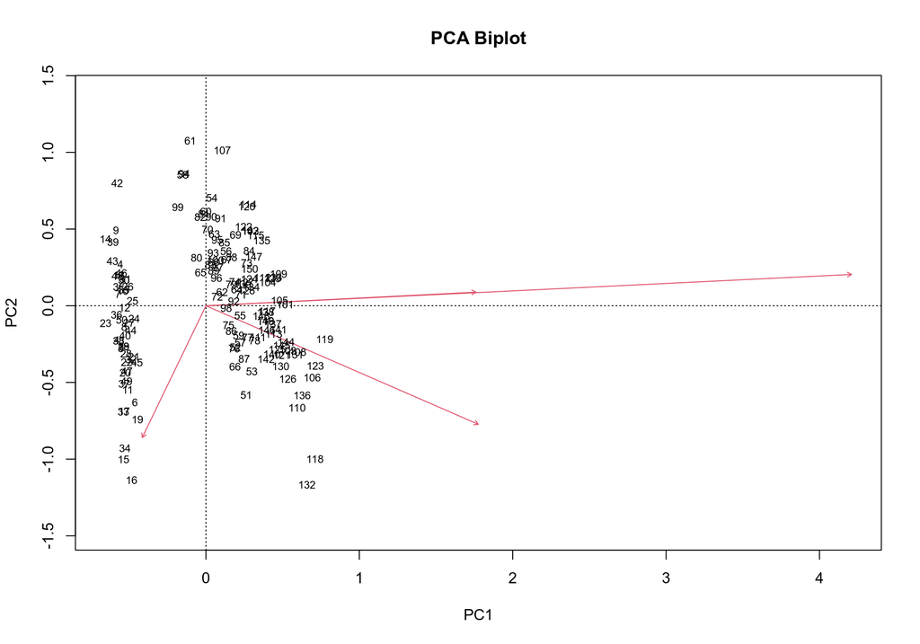

```r
# Альтернативная визуализация с векторами переменных
biplot(mod_pca, display = c("sites", "species"),
       type = c("points", "text"),
       main = "PCA Biplot")
```

## 4.7 Выводы по PCA

1. **Объяснённая дисперсия:**
   - PC1 объясняет 92.5% вариации данных.
   - PC1 + PC2 совместно объясняют 97.8% вариации.
   - Первые две компоненты достаточны для визуализации.
2. **Интерпретация главных компонент:**
   - PC1 определяется преимущественно Petal.Length и Petal.Width.
   - PC2 отражает вариацию в Sepal.Width.
3. **Разделение классов:**
   - Setosa чётко отделяется от других видов по PC1.
   - Versicolor и Virginica частично перекрываются.
   - Это согласуется с результатами KNN и SVM.

# Заключение

В ходе лабораторной работы были изучены и применены три метода анализа данных:

1. **KNN-классификация**:
   - Нормализация данных критически важна для работы алгоритма
   - Модель показала высокую точность на датасете iris
   - Оптимальное значение k следует подбирать экспериментально
2. **SVM-классификация**:
   - Линейный SVM эффективно работает с линейно разделимыми данными
   - 10-fold перекрестная проверка обеспечивает надёжную оценку качества
   - Метод устойчив к выбросам благодаря использованию опорных векторов
3. **Анализ главных компонент**:
   - Позволяет визуализировать многомерные данные в 2D
   - Первые две компоненты объясняют большую часть вариации
   - Подтверждает наблюдения о структуре данных iris

# Информация о сессии